# practical_exercise_2, Methods 3, 2021, autumn semester

# Assignment 1: Using mixed effects modelling to model hierarchical data

In this assignment we will be investigating the *politeness* dataset of Winter and Grawunder (2012) and apply basic methods of multilevel modelling.

```r
politeness <- read.csv('politeness.csv') ## read in data
```

## Exercise 1 - describing the dataset and making some initial plots

1. Describe the dataset, such that someone who happened upon this dataset could understand the variables and what they contain

**Subject**: Subject refers to the participant in the study

**Gender**: Gender of the participant - Male/Female

**Scenario**: Scenario is the task they are asked to do. There are 7 different scenarios eg. including “asking for a favour”.

**Attitude**: Either formal or informal. The participants were asked to do each scenario in a formal and informal way.

**Total duration**: Duration of participant response.

**f0mn**: The frequency of the response.

**hiss_count**: The amount of “noisy breath intakes” during the response.

````
i. Also consider whether any of the variables in _politeness_ should be encoded as factors or have the factor encoding removed. Hint: ```?factor```
````

```r
# Changing characters to factors.
politeness[sapply(politeness, is.character)] <- lapply(politeness[sapply(politeness, is.character)], as.factor)
```

2. Create a new data frame that just contains the subject *F1* and run two linear models; one that expresses *f0mn* as dependent on *scenario* as an integer; and one that expresses *f0mn* as dependent on *scenario* encoded as a factor

```r
F1 <- politeness %>%
  filter(subject == "F1")

# Model with scenario as integer
F1model1 <- lm(f0mn ~ scenario, F1)

# Changing scenario from numeric to factor.
F1$scenario <- as.factor(F1$scenario)

# Model with scenario as factor.
F1model2 <- lm(f0mn ~ scenario, F1)
```

```
i. Include the model matrices, $X$ from the General Linear Model, for these two models in your report and describe the different interpretations of _scenario_ that these entail
```

```r
print(model.matrix(F1model1))
```

```
##    (Intercept) scenario
## 1            1        1
## 2            1        1
## 3            1        2
## 4            1        2
## 5            1        3
## 6            1        3
## 7            1        4
## 8            1        4
## 9            1        5
## 10           1        5
## 11           1        6
## 12           1        6
## 13           1        7
## 14           1        7
## attr(,"assign")
## [1] 0 1
```

```r
print(model.matrix(F1model2))
```

```
##    (Intercept) scenario2 scenario3 scenario4 scenario5 scenario6 scenario7
## 1            1         0         0         0         0         0         0
## 2            1         0         0         0         0         0         0
## 3            1         1         0         0         0         0         0
## 4            1         1         0         0         0         0         0
## 5            1         0         1         0         0         0         0
## 6            1         0         1         0         0         0         0
## 7            1         0         0         1         0         0         0
## 8            1         0         0         1         0         0         0
## 9            1         0         0         0         1         0         0
## 10           1         0         0         0         1         0         0
## 11           1         0         0         0         0         1         0
## 12           1         0         0         0         0         1         0
## 13           1         0         0         0         0         0         1
## 14           1         0         0         0         0         0         1
## attr(,"assign")
## [1] 0 1 1 1 1 1 1
## attr(,"contrasts")
## attr(,"contrasts")$scenario
## [1] "contr.treatment"
```

[output not shown]

```
ii. Which coding of _scenario_, as a factor or not, is more fitting?
```

The coding of scenario as a factor is more fitting since scenario is a nominal variable.Since the scenarios are nominal and cannot be ‘compared’ to each other. When treating the variable as nominal it is assumed that scenario 1 is double as much as scenario 2. This is not the case and all scenarios need to ‘weigh’ as much as each other.

```r
politeness$scenario <- as.factor(politeness$scenario)
```

3. Make a plot that includes a subplot for each subject that has *scenario* on the x-axis and *f0mn* on the y-axis and where points are colour coded according to *attitude*

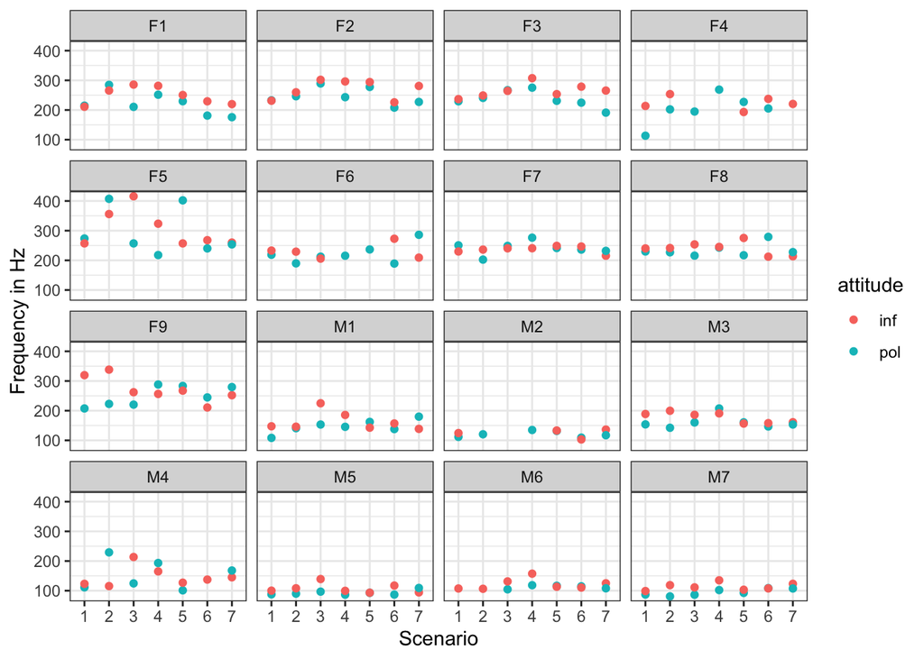

```
i. Describe the differences between subjects
```

```r
ggplot(politeness, aes(scenario, f0mn, colour=attitude))+
  geom_point()+
  facet_wrap(~ subject)+
  theme_bw()+
  ylab("Frequency in Hz")+
  xlab("Scenario")
```

It is visible that male subjects overall has lower frequencies than female subjects. It can also be seen that the effect of attitude is greater for some subjects than others.

## Exercise 2 - comparison of models

1. Build four models and do some comparisons
   1. a single level model that models *f0mn* as dependent on *gender*

```r
mi <- lm(f0mn ~ gender, politeness)
summary(mi)
```

```
##
## Call:
## lm(formula = f0mn ~ gender, data = politeness)
##
## Residuals:
##      Min       1Q   Median       3Q      Max
## -134.283  -24.928   -6.783   20.517  168.217
##
## Coefficients:
##             Estimate Std. Error t value Pr(>|t|)
## (Intercept)  247.583      3.588   69.01   <2e-16 ***
## genderM     -115.821      5.476  -21.15   <2e-16 ***
## ---
## Signif. codes:  0 '***' 0.001 '**' 0.01 '*' 0.05 '.' 0.1 ' ' 1
##
## Residual standard error: 39.46 on 210 degrees of freedom
##   (12 observations deleted due to missingness)
## Multiple R-squared:  0.6806, Adjusted R-squared:  0.679
## F-statistic: 447.4 on 1 and 210 DF,  p-value: < 2.2e-16
```

```
ii. a two-level model that adds a second level on top of i. where unique intercepts are modelled for each _scenario_
```

```r
mii <- lmer(f0mn ~ gender + (1|scenario), politeness)
summary(mii)
```

```
## Linear mixed model fit by REML ['lmerMod']
## Formula: f0mn ~ gender + (1 | scenario)
##    Data: politeness
##
## REML criterion at convergence: 2144.3
##
## Scaled residuals:
##     Min      1Q  Median      3Q     Max
## -3.2314 -0.6033 -0.1599  0.4893  4.2069
##
## Random effects:
##  Groups   Name        Variance Std.Dev.
##  scenario (Intercept)   91.77   9.579
##  Residual             1478.25  38.448
## Number of obs: 212, groups:  scenario, 7
##
## Fixed effects:
##             Estimate Std. Error t value
## (Intercept)  247.786      5.033   49.23
## genderM     -115.875      5.338  -21.71
##
## Correlation of Fixed Effects:
##         (Intr)
## genderM -0.455
```

```
iii. a two-level model that only has _subject_ as an intercept
```

```r
miii <- lmer(f0mn ~ gender + (1|subject), politeness)
summary(miii)
```

```
## Linear mixed model fit by REML ['lmerMod']
## Formula: f0mn ~ gender + (1 | subject)
##    Data: politeness
##
## REML criterion at convergence: 2091.6
##
## Scaled residuals:
##     Min      1Q  Median      3Q     Max
## -3.2200 -0.5402 -0.1385  0.4358  3.8184
##
## Random effects:
##  Groups   Name        Variance Std.Dev.
##  subject  (Intercept)  595.1   24.39
##  Residual             1026.7   32.04
## Number of obs: 212, groups:  subject, 16
##
## Fixed effects:
##             Estimate Std. Error t value
## (Intercept)  246.525      8.641  28.531
## genderM     -115.181     13.080  -8.806
##
## Correlation of Fixed Effects:
##         (Intr)
## genderM -0.661
```

```
iv. a two-level model that models intercepts for both _scenario_ and _subject_
```

```r
miv <- lmer(f0mn ~ gender + (1|subject) + (1|scenario), politeness)
summary(miv)
```

```
## Linear mixed model fit by REML ['lmerMod']
## Formula: f0mn ~ gender + (1 | subject) + (1 | scenario)
##    Data: politeness
##
## REML criterion at convergence: 2082.5
##
## Scaled residuals:
##     Min      1Q  Median      3Q     Max
## -3.0131 -0.5373 -0.1089  0.4381  3.7558
##
## Random effects:
##  Groups   Name        Variance Std.Dev.
##  subject  (Intercept) 588.83   24.266
##  scenario (Intercept)  96.17    9.807
##  Residual             939.92   30.658
## Number of obs: 212, groups:  subject, 16; scenario, 7
##
## Fixed effects:
##             Estimate Std. Error t value
## (Intercept)  246.765      9.327   26.46
## genderM     -115.175     12.955   -8.89
##
## Correlation of Fixed Effects:
##         (Intr)
## genderM -0.606
```

```
v. which of the models has the lowest residual standard deviation, also compare the Akaike Information Criterion `AIC`?
```

```r
model_text <- c("model i", "model ii", "model iii", "model iv")
sigmas <- c(sigma(mi),sigma(mii),sigma(miii), sigma(miv))
AIC <- c(AIC(mi), AIC(mii), AIC(miii), AIC(miv))
mtable <- as_tibble(cbind(model_text,sigmas,AIC))
mtable
```

| model_text | sigmas | AIC |
| --- | --- | --- |
| model i | 39.4626791688879 | 2163.97113146109 |
| model ii | 38.4480006729009 | 2152.31407750122 |
| model iii | 32.0428716618224 | 2099.62649319673 |
| model iv | 30.6580347795662 | 2092.48213331604 |

The two level model with subject and scenario as random intercepts has the lowest AIC and residual standard deviation.

```
vi. which of the second-level effects explains the most variance?
```

Subject as second level effect explains more variance, underlined by lower residual standard deviation and AIC than the scenario as second level effect. Furthermore, the difference in residual standard deviation and AIC between the model with subject as the only second-level effect and the model with both subject and scenario as second-level, is smaller than the difference between the models with subject and scenario as random intercepts. This indicates that more variance is explained by subject than scenario.

2. Why is our single-level model bad? It does not take individual pitch frequency differences into account.

```
i. create a new data frame that has three variables, _subject_, _gender_ and _f0mn_, where _f0mn_ is the average of all responses of each subject, i.e. averaging across _attitude_ and_scenario_
```

```r
new_df <- politeness %>%
  na.omit() %>%
  group_by(subject, gender) %>%
  summarise(avg_f0mn=(mean(f0mn)))
```

```
ii. build a single-level model that models _f0mn_ as dependent on _gender_ using this new dataset
```

```r
mii2 <- lm(avg_f0mn ~ gender, new_df)
```

[output not shown]

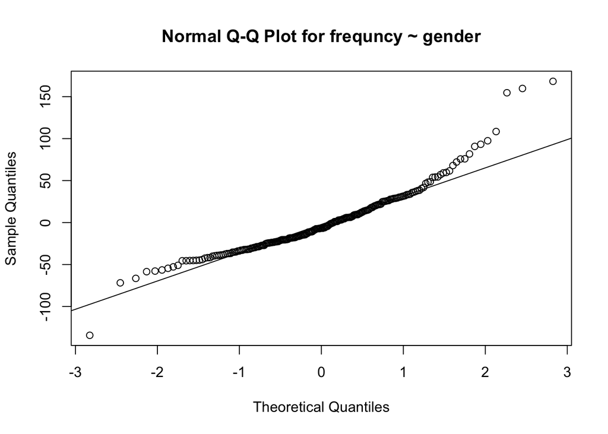

```r
qqnorm(resid(mi), main = "Normal Q-Q Plot for frequncy ~ gender")
qqline(resid(mi))
```

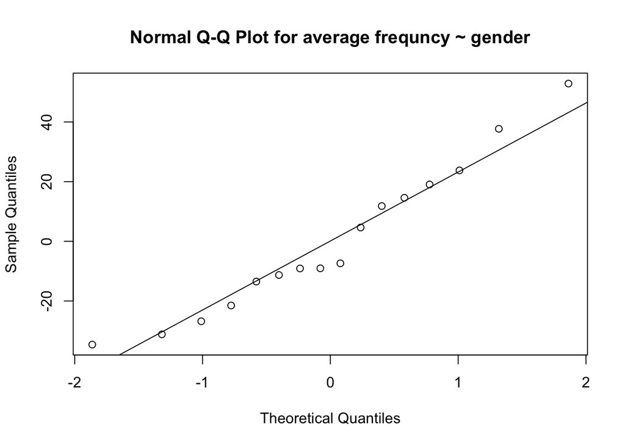

```r
qqnorm(resid(mii2), main = "Normal Q-Q Plot for average frequncy ~ gender")
qqline(resid(mii2))
```

The residuals ($\epsilon$) of the model averaging over frequencies across trials fulfill the assumptions of the General Linear Model better. The residuals seems more equally distributed around the line indicating normality compared to the one-level model which seems to systematically underestimate the sample values.

```
iv. Also make a quantile-quantile plot for the residuals of the  multilevel model with two intercepts. Does it look alright?
```

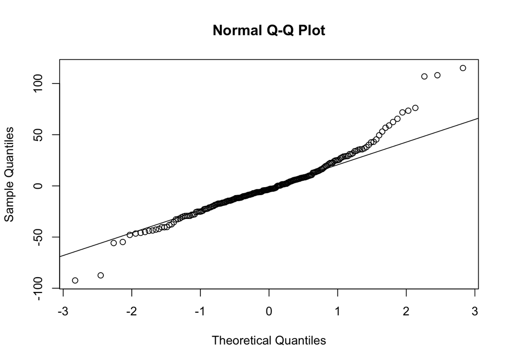

```r
qqnorm(resid(miv))
qqline(resid(miv))
```

Compared to the one-level model, the residuals seems slightly more evenly distributed around the line. Some deviation is visible around the 2nd and 3rd quantile but overall it seems to fulfill the assumption of normality of residuals.

3. Plotting the two-intercepts model
   1. Create a plot for each subject, (similar to part 3 in Exercise 1), this time also indicating the fitted value for each of the subjects for each for the scenarios (hint use `fixef` to get the “grand effects” for each gender and `ranef` to get the subject- and scenario-specific effects)

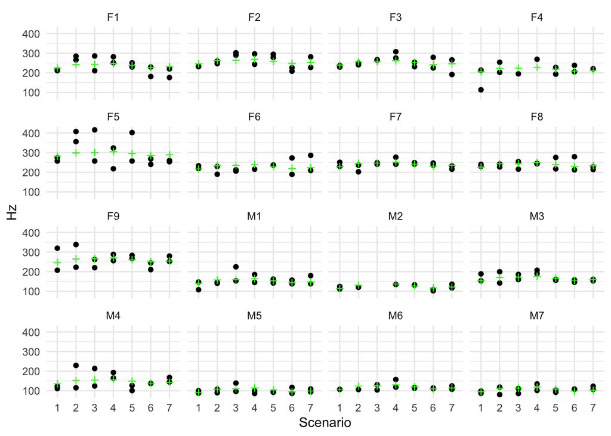

```r
politeness <- politeness %>% na.omit(politeness)
politeness$yhat <- predict(miv)

ggplot(politeness, aes(x = scenario, y = f0mn))+
  geom_point() +
  geom_point(aes(x = scenario, y = yhat),color = 'green', shape = 3) +
  facet_wrap(~ subject)+
  xlab('Scenario') +
  ylab('Hz') +
  theme_minimal()
```

Plot illustrating frequency across scenarios for each subjects. The black dots represents the observed values and the green crosses represents the estimated values.

## Exercise 3 - now with attitude

1. Carry on with the model with the two unique intercepts fitted (*scenario* and *subject*).
   1. now build a model that has *attitude* as a main effect besides *gender*

```r
mi3 <- lmer(f0mn ~ gender + attitude + (1|subject) + (1|scenario), politeness)
summary(mi3)
```

```
## Linear mixed model fit by REML ['lmerMod']
## Formula: f0mn ~ gender + attitude + (1 | subject) + (1 | scenario)
##    Data: politeness
##
## REML criterion at convergence: 2065.1
##
## Scaled residuals:
##     Min      1Q  Median      3Q     Max
## -2.8511 -0.6081 -0.0602  0.4329  3.8745
##
## Random effects:
##  Groups   Name        Variance Std.Dev.
##  subject  (Intercept) 585.6    24.20
##  scenario (Intercept) 106.7    10.33
##  Residual             882.7    29.71
## Number of obs: 212, groups:  subject, 16; scenario, 7
##
## Fixed effects:
##             Estimate Std. Error t value
## (Intercept)  254.398      9.597  26.507
## genderM     -115.437     12.881  -8.962
## attitudepol  -14.819      4.096  -3.618
##
## Correlation of Fixed Effects:
##             (Intr) gendrM
## genderM     -0.587
## attitudepol -0.220  0.006
```

ii. make a separate model that besides the main effects of *attitude* and *gender* also include their interaction

```r
mii3 <- lmer(f0mn ~ gender * attitude + (1|subject) + (1|scenario), politeness)
summary(mii3)
```

```
## Linear mixed model fit by REML ['lmerMod']
## Formula: f0mn ~ gender * attitude + (1 | subject) + (1 | scenario)
##    Data: politeness
##
## REML criterion at convergence: 2058.6
##
## Scaled residuals:
##     Min      1Q  Median      3Q     Max
## -2.8120 -0.5884 -0.0645  0.4014  3.9100
##
## Random effects:
##  Groups   Name        Variance Std.Dev.
##  subject  (Intercept) 584.4    24.17
##  scenario (Intercept) 106.4    10.32
##  Residual             885.5    29.76
## Number of obs: 212, groups:  subject, 16; scenario, 7
##
## Fixed effects:
##                     Estimate Std. Error t value
## (Intercept)          255.618      9.761  26.186
## genderM             -118.232     13.531  -8.738
## attitudepol          -17.192      5.423  -3.170
## genderM:attitudepol    5.544      8.284   0.669
##
## Correlation of Fixed Effects:
##             (Intr) gendrM atttdp
## genderM     -0.606
## attitudepol -0.286  0.206
## gndrM:tttdp  0.187 -0.309 -0.654
```

```
iii. describe what the interaction term in the model says about Korean men's pitch when they are polite relative to Korean women's pitch when they are polite (you don't have to judge whether it is interesting)
```

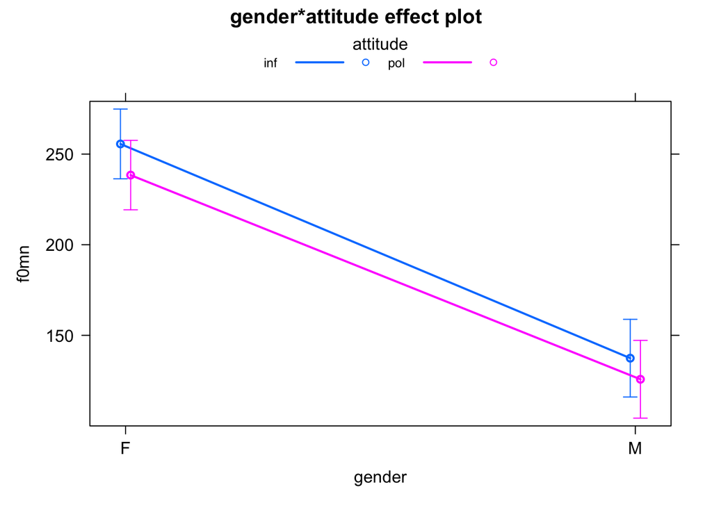

```r
plot(allEffects(mii3), multiline=TRUE, ci.style="bars")
```

2. Compare the three models (1. gender as a main effect; 2. gender and attitude as main effects; 3. gender and attitude as main effects and the interaction between them. For all three models model unique intercepts for *subject* and *scenario*) using residual variance, residual standard deviation and AIC.

```r
model <- c("Model miv", "Model mi3", "Model mii3")
sigmas <- c(sigma(miv),sigma(mi3),sigma(mii3))
residual_variance <- c(var(resid(miv)), var(resid(mi3)), var(resid(mii3)))
AIC <- c(AIC(miv),AIC(mi3), AIC(mii3))

residual3 <- as_tibble(cbind(model,sigmas, residual_variance, AIC))
residual3
```

| model | sigmas | residual_variance | AIC |
| --- | --- | --- | --- |
| Model miv | 30.6580347795662 | 859.679825614985 | 2092.48213331604 |
| Model mi3 | 29.7108691326764 | 802.147790350729 | 2077.13120691067 |
| Model mii3 | 29.7568374031342 | 800.491065832863 | 2072.61767572572 |

The model with gender as main effect has the highest residual variance, residual standard deviation and the highest AIC. Of the two models with attitude and gender as main effects the residual standard deviation is close to equal and the residual variance and AIC is sligthly smaller for the model including the interaction effect.

The following is written in collaboration with all of study group four.

3. Choose the model that you think describe the data the best - and write a short report on the main findings based on this model. The data set consists of frequency measurements of 7 men and 9 women. Their voice frequency was measured over 7 different scenarios, in two different attitudes - polite and informal. This means all participants went through 14 trials in total (except for a few missing values). Other variables include gender, hiss count and total duration of the specific trial.

After running different models on the data, the following model was chosen to investigate the effect of gender and attitude on pitch.

*frequency ~ gender + attitude + (1 | subject) + (1 | scenario)*

The dependent variable is the pitch frequency, the fixed effects include gender and attitude and subject and scenario are modelled as random intercepts. Since humans naturally have different pitch frequencies, and what we are interested in is how it is changed under certain circumstances, it is relevant to include random intercepts for each subject. If it was not included, the model would not take into account the repeated measurement design of the experiment. Furthermore, if you do not include random intercepts, you would overlook a very clear underlying effect in the data, thus having the risk of not interpreting the model properly. Therefore, including random intercepts for subject and scenario was found important.

After building the model a quantile-quantile plot of the chosen model was made testing for the assumption of normality of the residuals.

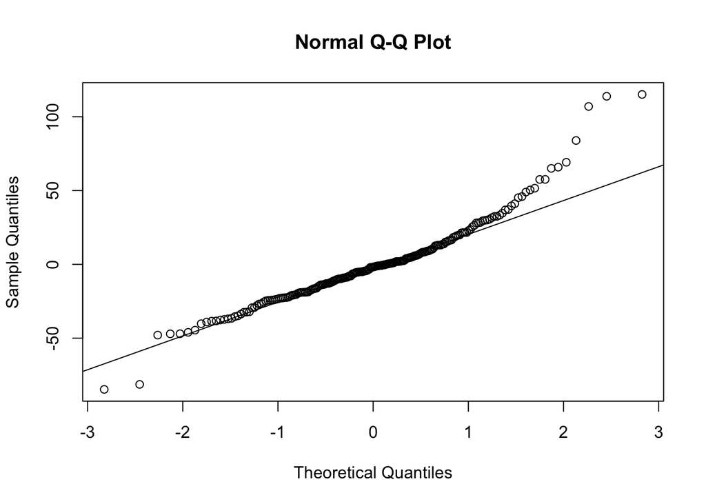

```r
qqnorm(resid(mi3))
qqline(resid(mi3))
```

Figure 1. Quantile Quantile plot for the residuals of the multilevel model.

In evaluation of the plot, it was concluded that the model fulfilled the assumption, since most of the points are on the straight line, and we only see a small pattern of deviation at the end of the line.

We see that there is a higher variance (585.6) and std. dev. (24.20) for the second level effect subject compared to the second level effect of scenario where variance (106.7) and std. dev. (10.33) which means that there is a higher variability within *subjects* compared to *scenarios*.

The special thing shown by our model is that both Korean men and womens frequency gets lower in polite scenarios compared to informal scenarios, whereas in many other languages it is the opposite, when in polite scenarios the pitch gets higher for both men and women (Winter, 2013) ergo there are also cultural differences.